# Field excursion Chile 2022

25/11/2021

## Study sites

[interactive chart not shown]

Study sites

## New Study sites

[interactive chart not shown]

New study sites

## Quebrada de Talca

- Soil:
- Glaciar influence: NO
- Volcanic influence: NO
- Climate: Desert with marine influence and xeric humidity regime (BWnXe)
- MAP: 66 mm
- MAP:
- ET<sub>0</sub>: 1382 mm
- MAT:
- Administration: Private (Comunidad Agrícola de Quebrada de Talca)
- Distance from Santiago: ~400 km (6-7 hr driving time)

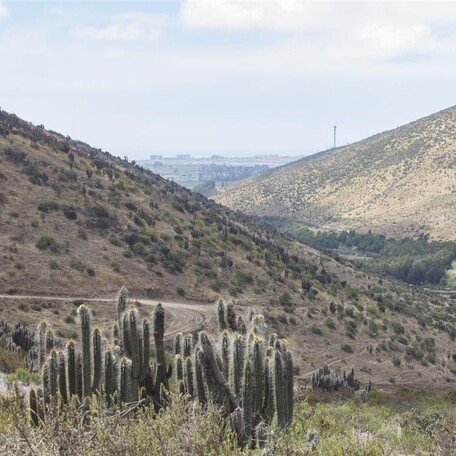

## Parque Nacional Alerce Costero

- Soil:
- Glaciar influence: NO
- Volcanic influence:
- Climate: Warm temperate mesothermal with per-humid humidity regime (Cfb1pH)
- MAP: 1951 mm
- ET<sub>0</sub>: 122
- MAT:
- Administration: CONAF
- Distance from Santiago: ~930 km (10-11 hr driving time)

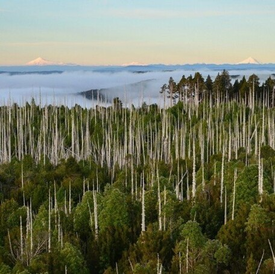

## Reserva Costera Valdiviana

- Soil:
- Glaciar influence: NO
- Volcanic influence:
- Climate: Warm temperate mesothermal with per-humid humidity regime (Cfb1pH)
- MAP: 1951 mm
- ET<sub>0</sub>: 122
- MAT:
- Administration: private (The Nature Conservancy)
- Distance from Santiago: ~970 km (10-11 hr driving time)

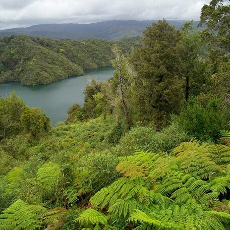

## Parque Nacional Chiloé

- Soil:
- Glaciar influence: YES
- Volcanic influence:
- Climate: Warm temperate mesothermal with per-humid humidity regime (Cfb1pH)
- MAP: 2181 mm
- ET<sub>0</sub>: 5 mm
- MAT:
- Administration: CONAF
- Distance from Santiago: ~1250 km (14-15 hr driving time)

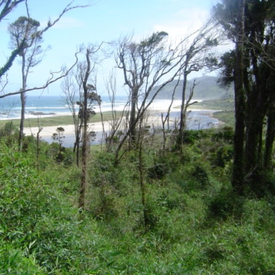